# Análise de Extremos Climáticos: Novembro

Investigação de Tendências em Séries Temporais (1968-2022)

Lucas Pereira Belo

2026-02-10

Pacotes utilizados

```r
library(readxl)
library(dplyr)
library(ggplot2)    # Gráficos avançados
library(tseries)    # Testes de séries temporais
library(trend)      # Testes não-paramétricos (MK, Cox-Stuart)
library(goftest)    # Testes de bondade de ajuste (AD)
library(extRemes)   # Modelagem GEV
library(urca)       # Testes de raiz unitária
library(kableExtra) # Tabelas formatadas
library(distillery)
library(randtests)  # Runs Test
```

# 1 Leitura e preparação dos dados

```r
# ==============================================================================
# LEITURA E PREPARAÇÃO DOS DADOS
# ==============================================================================
# Ajuste o caminho do arquivo conforme necessário
df_nov <- read_excel("EXTREMOS.xlsx", sheet = 11) # Sheet 11 = Novembro

# Criação do DataFrame de Trabalho (limpo de NAs)
anos <- seq(1968, 2022, 1)
df_analise <- data.frame(Ano = anos, Temp = df_nov$TEMP)
df_analise <- na.omit(df_analise)

# Metadados para os gráficos
NOME_MES <- "Novembro"
```

# 2 Diagnóstico

```r
# ==============================================================================
# FUNÇÕES DE APOIO (Diagnóstico e Validação)
# ==============================================================================

# 1. Função de Plotagem da Série
plot_serie_inicial <- function(dados, anos, nome) {
  df <- data.frame(Ano = anos, Temp = dados)
  media <- mean(df$Temp)
  tendencia <- coef(lm(Temp ~ Ano, data = df))[2]

  ggplot(df, aes(x = Ano, y = Temp)) +
    geom_line(color = "gray50", size = 0.8) +
    geom_point(color = "#2c3e50", size = 2) +
    geom_smooth(method = "lm", se = FALSE, color = "#c0392b", size = 1) +
    geom_hline(yintercept = media, color = "#2980b9", linetype = "dashed") +
    theme_minimal() +
    labs(title = paste("Série Histórica:", nome),
         subtitle = paste0("Tendência Linear: ", round(tendencia, 3), " °C/ano"),
         y = "Temperatura Máxima (°C)", x = "Ano")
}

# 2. Função de Validação (KS e AD) com Histograma PIT
validar_modelo <- function(modelo, nome_mod) {
  # PIT (Probability Integral Transform)
  z <- pextRemes(modelo, q = modelo$x, lower.tail = TRUE)
  z <- na.omit(as.numeric(z))

  # Testes
  ks <- ks.test(z, "punif")
  ad <- ad.test(z, "punif")

  # Badge
  badge <- function(p) {
    if(p > 0.05) "<span style='background:#27ae60; color:white; padding:2px 6px; border-radius:4px;'>Adequado</span>"
    else "<span style='background:#c0392b; color:white; padding:2px 6px; border-radius:4px;'>Inadequado</span>"
  }

  # Tabela
  df_res <- data.frame(
    Teste = c("Kolmogorov-Smirnov", "Anderson-Darling"),
    Estatistica = c(round(ks$statistic, 4), round(ad$statistic, 4)),
    P_Valor = c(format.pval(ks$p.value, digits=4), format.pval(ad$p.value, digits=4)),
    Conclusao = c(badge(ks$p.value), badge(ad$p.value))
  )

  print(kbl(df_res, caption = paste("Validação:", nome_mod), escape = F, align = "c") %>%
        kable_styling(bootstrap_options = "striped", full_width = F))

  # Histograma PIT
  par(mfrow=c(1,1))
  hist(z, breaks = seq(0, 1, 0.1), freq = FALSE, col="#ecf0f1", border="#7f8c8d",
       main = paste("Histograma PIT:", nome_mod), xlab = "Probabilidade (z)")
  abline(h=1, col="#c0392b", lwd=2, lty=2)
}
```

# 3 Análise Exploratória

A primeira etapa consiste na visualização da série temporal e na aplicação de testes estatísticos para verificar a presença de tendências monotônicas, estacionariedade e dependência serial.

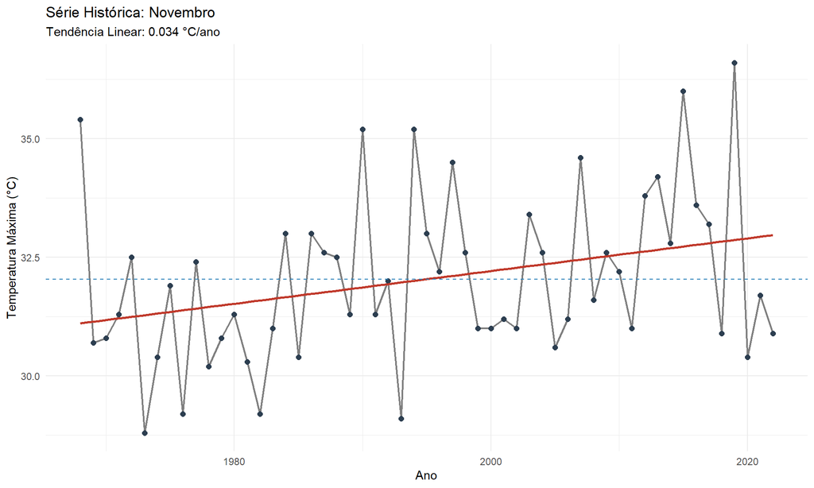

```r
# 1. Visualização
plot_serie_inicial(df_analise$Temp, df_analise$Ano, NOME_MES)
```

```r
# 2. Testes Preliminares
mk_res <- mk.test(df_analise$Temp)
cs_res <- cox.stuart.test(df_analise$Temp)
adf_res <- adf.test(df_analise$Temp, alternative = "stationary")
lb_res <- Box.test(df_analise$Temp, type = "Ljung-Box")

# Tabela de Diagnóstico
df_diag <- data.frame(
  Teste = c("Mann-Kendall (Tendência)", "Cox-Stuart (Tendência)", "ADF (Estacionariedade)", "Ljung-Box (Independência)"),
  H0 = c("Sem Tendência", "Sem Tendência", "Não-Estacionário", "Independência"),
  P_Valor = c(format.pval(mk_res$p.value, digits=3), format.pval(cs_res$p.value, digits=3),
              format.pval(adf_res$p.value, digits=3), format.pval(lb_res$p.value, digits=3))
)

print(kbl(df_diag, caption = "Diagnóstico Estatístico Preliminar", align = "c") %>%
      kable_styling(bootstrap_options = c("hover", "condensed"), full_width = F))
```

Diagnóstico Estatístico Preliminar

| Teste | H0 | P_Valor |
| --- | --- | --- |
| Mann-Kendall (Tendência) | Sem Tendência | 0.0196 |
| Cox-Stuart (Tendência) | Sem Tendência | 0.0755 |
| ADF (Estacionariedade) | Não-Estacionário | 0.318 |
| Ljung-Box (Independência) | Independência | 0.99 |

```r
cat("\n**Interpretação:** P-valores < 0.05 indicam rejeição da hipótese nula (H0).")
```

**Interpretação:** P-valores < 0.05 indicam rejeição da hipótese nula (H0).

Ajuste e Seleção de Modelos GEV

```r
# ==============================================================================
# 1. AJUSTE DOS MODELOS (M0 a M4)
# ==============================================================================

# M0: Estacionário (Referência)
fit0 <- fevd(Temp, data = df_analise, type = "GEV", units = "deg C")

# M1: Tendência apenas na Média (Locação)
fit1 <- fevd(Temp, data = df_analise, location.fun = ~Ano, type = "GEV")

# M2: Tendência na Média e Variabilidade (Locação + Escala)
# Nota: Usamos use.phi=TRUE para garantir variância positiva
fit2 <- fevd(Temp, data = df_analise, location.fun = ~Ano, scale.fun = ~Ano,
             use.phi = TRUE, type = "GEV")

# M3: O NOVO MODELO (Locação + Forma, Escala Fixa)
# Testamos se os extremos (shape) mudam junto com a média, mas a variância base é estável.
fit3 <- fevd(Temp, data = df_analise, location.fun = ~Ano, shape.fun = ~Ano, type = "GEV")

# M4: Modelo Completo (Locação + Escala + Forma)
fit4 <- fevd(Temp, data = df_analise, location.fun = ~Ano, scale.fun = ~Ano, shape.fun = ~Ano,
             use.phi = TRUE, type = "GEV")

# ==============================================================================
# 2. SELEÇÃO E TABELA COMPARATIVA
# ==============================================================================

# Extração manual dos critérios (AIC e BIC)
aic_vals <- c(summary(fit0)$AIC, summary(fit1)$AIC, summary(fit2)$AIC, summary(fit3)$AIC, summary(fit4)$AIC)
```

fevd(x = Temp, data = df_analise, type = “GEV”, units = “deg C”)

[1] “Estimation Method used: MLE”

Negative Log-Likelihood Value: 106.7404

Estimated parameters: location scale shape 31.3034596 1.5249930 -0.1091795

Standard Error Estimates: location scale shape 0.23094668 0.16343006 0.09880836

Estimated parameter covariance matrix. location scale shape location 0.053336367 0.009791675 -0.008697158 scale 0.009791675 0.026709383 -0.006682318 shape -0.008697158 -0.006682318 0.009763091

AIC = 219.4807

BIC = 225.5027

fevd(x = Temp, data = df_analise, location.fun = ~Ano, type = “GEV”)

[1] “Estimation Method used: MLE”

Negative Log-Likelihood Value: 103.4567

Estimated parameters: mu0 mu1 scale shape -32.11049249 0.03179372 1.40821655 -0.07582834

AIC = 214.9134

BIC = 222.9427

fevd(x = Temp, data = df_analise, location.fun = ~Ano, scale.fun = ~Ano, use.phi = TRUE, type = “GEV”)

[1] “Estimation Method used: MLE”

Negative Log-Likelihood Value: 103.4275

Estimated parameters: mu0 mu1 phi0 phi1 shape -31.908228170 0.031692737 -1.856067951 0.001102141 -0.077301642

AIC = 216.855

BIC = 226.8916

fevd(x = Temp, data = df_analise, location.fun = ~Ano, shape.fun = ~Ano, type = “GEV”)

[1] “Estimation Method used: MLE”

Negative Log-Likelihood Value: 103.4874

Estimated parameters: mu0 mu1 scale xi0 xi1 -24.409363622 0.027929375 1.400751248 -3.582059387 0.001762888

AIC = 216.9748

BIC = 227.0115

fevd(x = Temp, data = df_analise, location.fun = ~Ano, scale.fun = ~Ano, shape.fun = ~Ano, use.phi = TRUE, type = “GEV”)

[1] “Estimation Method used: MLE”

Negative Log-Likelihood Value: 103.4654

Estimated parameters: mu0 mu1 phi0 phi1 xi0 -3.089611e+01 3.118293e-02 -4.091997e+00 2.221817e-03 -1.899682e+00 xi1 9.173297e-04

AIC = 218.9308

BIC = 230.9748

```r
bic_vals <- c(summary(fit0)$BIC, summary(fit1)$BIC, summary(fit2)$BIC, summary(fit3)$BIC, summary(fit4)$BIC)
```

fevd(x = Temp, data = df_analise, type = “GEV”, units = “deg C”)

[1] “Estimation Method used: MLE”

Negative Log-Likelihood Value: 106.7404

Estimated parameters: location scale shape 31.3034596 1.5249930 -0.1091795

Standard Error Estimates: location scale shape 0.23094668 0.16343006 0.09880836

Estimated parameter covariance matrix. location scale shape location 0.053336367 0.009791675 -0.008697158 scale 0.009791675 0.026709383 -0.006682318 shape -0.008697158 -0.006682318 0.009763091

AIC = 219.4807

BIC = 225.5027

fevd(x = Temp, data = df_analise, location.fun = ~Ano, type = “GEV”)

[1] “Estimation Method used: MLE”

Negative Log-Likelihood Value: 103.4567

Estimated parameters: mu0 mu1 scale shape -32.11049249 0.03179372 1.40821655 -0.07582834

AIC = 214.9134

BIC = 222.9427

fevd(x = Temp, data = df_analise, location.fun = ~Ano, scale.fun = ~Ano, use.phi = TRUE, type = “GEV”)

[1] “Estimation Method used: MLE”

Negative Log-Likelihood Value: 103.4275

Estimated parameters: mu0 mu1 phi0 phi1 shape -31.908228170 0.031692737 -1.856067951 0.001102141 -0.077301642

AIC = 216.855

BIC = 226.8916

fevd(x = Temp, data = df_analise, location.fun = ~Ano, shape.fun = ~Ano, type = “GEV”)

[1] “Estimation Method used: MLE”

Negative Log-Likelihood Value: 103.4874

Estimated parameters: mu0 mu1 scale xi0 xi1 -24.409363622 0.027929375 1.400751248 -3.582059387 0.001762888

AIC = 216.9748

BIC = 227.0115

fevd(x = Temp, data = df_analise, location.fun = ~Ano, scale.fun = ~Ano, shape.fun = ~Ano, use.phi = TRUE, type = “GEV”)

[1] “Estimation Method used: MLE”

Negative Log-Likelihood Value: 103.4654

Estimated parameters: mu0 mu1 phi0 phi1 xi0 -3.089611e+01 3.118293e-02 -4.091997e+00 2.221817e-03 -1.899682e+00 xi1 9.173297e-04

AIC = 218.9308

BIC = 230.9748

```r
# Montagem da Tabela
nomes_modelos <- c("M0: Estacionário",
                   "M1: Locação",
                   "M2: Loc. + Escala",
                   "M3: Loc. + Forma",
                   "M4: Completo (Loc+Esc+Shp)")

df_comp <- data.frame(
  Modelo = nomes_modelos,
  AIC = round(aic_vals, 2),
  BIC = round(bic_vals, 2),
  Delta_AIC = round(aic_vals - min(aic_vals), 2)
)

# Identificando o Vencedor
vencedor_idx <- which.min(df_comp$AIC)
modelo_vencedor_nome <- df_comp$Modelo[vencedor_idx]

# Salva o objeto vencedor para os próximos passos
lista_modelos <- list(fit0, fit1, fit2, fit3, fit4)
obj_vencedor <- lista_modelos[[vencedor_idx]]

# Exibe Tabela com Destaque
print(kbl(df_comp, caption = "Comparativo de Modelos GEV - Novembro", align = "c") %>%
      kable_styling(bootstrap_options = "striped", full_width = F) %>%
      row_spec(vencedor_idx, bold = T, color = "white", background = "#27ae60"))
```

Comparativo de Modelos GEV - Novembro

| Modelo | AIC | BIC | Delta_AIC |
| --- | --- | --- | --- |
| M0: Estacionário | 219.48 | 225.50 | 4.57 |
| M1: Locação | 214.91 | 222.94 | 0.00 |
| M2: Loc. + Escala | 216.85 | 226.89 | 1.94 |
| M3: Loc. + Forma | 216.97 | 227.01 | 2.06 |
| M4: Completo (Loc+Esc+Shp) | 218.93 | 230.97 | 4.02 |

```r
cat(paste0("\n<div class='alert-success'>**Resultado:** O critério AIC selecionou o modelo **", modelo_vencedor_nome, "** como o mais adequado.</div>\n"))
```

**Resultado:** O critério AIC selecionou o modelo **M1: Locação** como o mais adequado.

# 4 Diagnóstico do Modelo Vencedor

Abaixo, realizamos a verificação da adequação do modelo selecionado através de testes formais de bondade de ajuste e inspeção visual dos resíduos.

```r
# 1. Parâmetros Estimados
cat("#### Parâmetros Estimados e Erro Padrão\n")
```

#### 4.0.0.1 Parâmetros Estimados e Erro Padrão

```r
print(obj_vencedor$results$par)
```

```
     mu0          mu1        scale        shape
```

-32.11049249 0.03179372 1.40821655 -0.07582834

```r
# 2. Testes de Adequação (KS e AD)
cat("\n#### Validação Estatística (Kolmogorov-Smirnov)\n")
```

#### 4.0.0.2 Validação Estatística (Kolmogorov-Smirnov)

```r
validar_modelo(obj_vencedor, modelo_vencedor_nome)
```

Validação: M1: Locação

|  | Teste | Estatistica | P_Valor | Conclusao |
| --- | --- | --- | --- | --- |
| D | Kolmogorov-Smirnov | 1 | < 2.2e-16 | Inadequado |
| An | Anderson-Darling | Inf | 1.091e-05 | Inadequado |

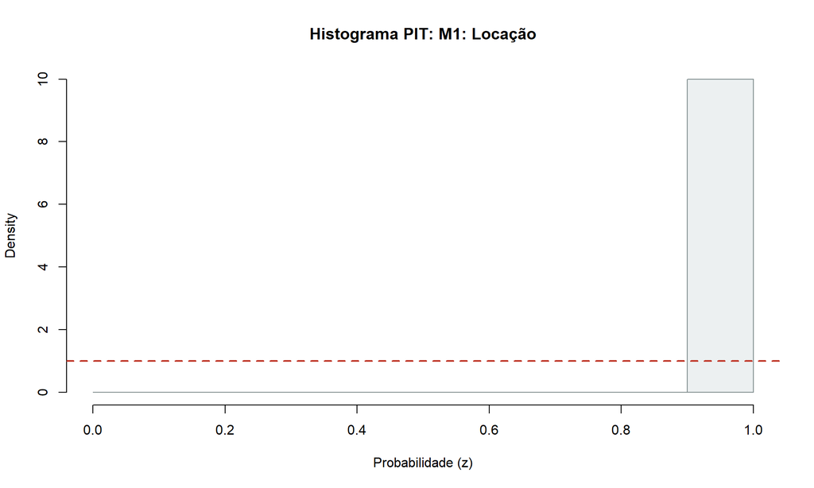

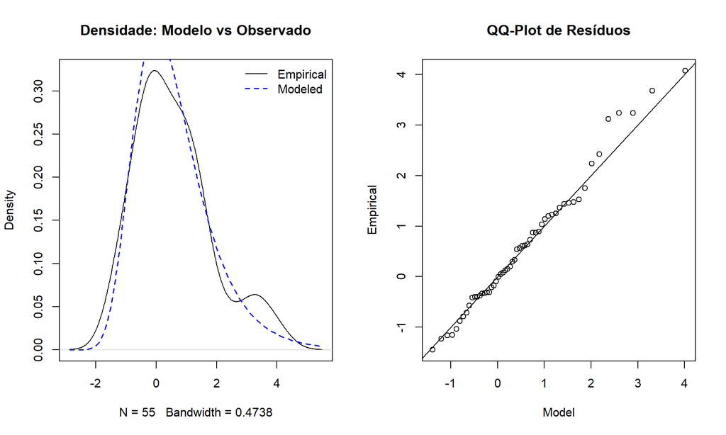

```r
# 3. Diagnóstico Visual Padrão
par(mfrow=c(1,2))
plot(obj_vencedor, type = "density", main = "Densidade: Modelo vs Observado")
plot(obj_vencedor, type = "qq", main = "QQ-Plot de Resíduos")
```

```r
par(mfrow=c(1,1))
```

Análise de Risco (Níveis de Retorno) Com base no modelo vencedor, projetamos os níveis de retorno para diferentes períodos de recorrência, destacando a evolução do risco ao longo do tempo (caso o modelo seja não-estacionário)

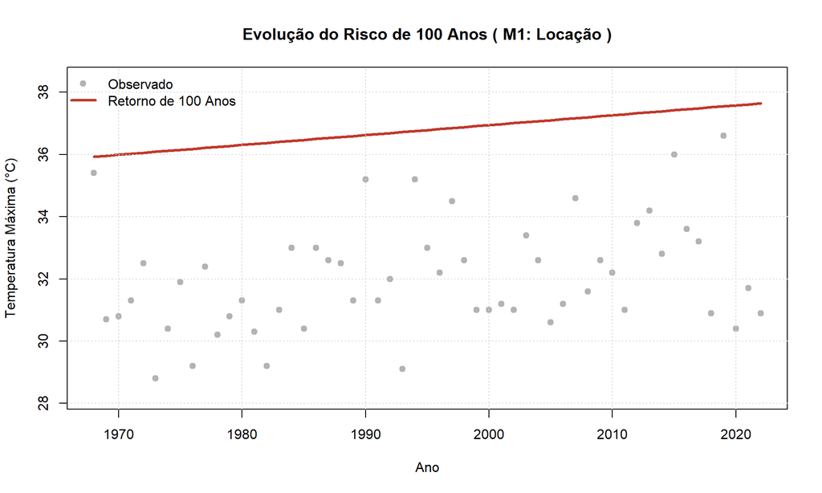

```r
# ==============================================================================
# PROJEÇÃO DE RISCO (GRÁFICO UNIVERSAL)
# ==============================================================================

# Se for M0 (Estacionário), faz o plot simples
if(modelo_vencedor_nome == "M0: Estacionário") {

  plot(obj_vencedor, type = "rl", main = "Níveis de Retorno (Estacionário)",
       rperiods = c(10, 50, 100), col = "#2c3e50")

} else {
  # CÁLCULO MANUAL ROBUSTO (Para modelos com tendência)

  params <- obj_vencedor$results$par
  anos_vec <- df_analise$Ano

  # --- 1. Montagem do Vetor de Locação (Mu) ---
  # Pega o intercepto (pode chamar 'location' ou 'mu0') e a inclinação ('mu1')
  mu_int <- if(is.na(params["mu0"])) params["location"] else params["mu0"]
  mu_inc <- if(is.na(params["mu1"])) 0 else params["mu1"]
  mu_t <- mu_int + mu_inc * anos_vec

  # --- 2. Montagem do Vetor de Escala (Sigma) ---
  # Se usou Log-Link (M2, M4), sigma = exp(a + b*t). Se não (M1, M3), sigma é fixo.
  if("log.scale" %in% names(params)) {
    sig_int <- params["log.scale"]
    sig_inc <- if(is.na(params["phi1"])) 0 else params["phi1"]
    sig_t <- exp(sig_int + sig_inc * anos_vec)
  } else {
    sig_int <- params["scale"]
    sig_inc <- 0 # Modelo sem tendência na escala
    sig_t <- sig_int
  }

  # --- 3. Montagem do Vetor de Forma (Xi) ---
  # Pega intercepto ('shape' ou 'xi0') e inclinação ('xi1')
  xi_int <- if(is.na(params["xi0"])) params["shape"] else params["xi0"]
  xi_inc <- if(is.na(params["xi1"])) 0 else params["xi1"]
  xi_t <- xi_int + xi_inc * anos_vec

  # --- 4. Fórmula do Nível de Retorno (GEV Inversa) ---
  periodo <- 100
  y_p <- -log(1 - 1/periodo)

  # Aplica a fórmula para cada ano
  rl_100 <- mu_t + (sig_t / xi_t) * ( (y_p^(-xi_t)) - 1 )

  # --- 5. Plotagem ---
  par(mfrow=c(1,1), mar=c(5, 4, 4, 2) + 0.1)

  # Limites dinâmicos para o gráfico
  y_max_plot <- max(c(df_analise$Temp, rl_100)) * 1.02
  y_min_plot <- min(df_analise$Temp) * 0.98

  plot(df_analise$Ano, df_analise$Temp, pch=19, col="gray70",
       main = paste("Evolução do Risco de 100 Anos (", modelo_vencedor_nome, ")"),
       ylab = "Temperatura Máxima (°C)", xlab = "Ano",
       ylim = c(y_min_plot, y_max_plot))

  lines(df_analise$Ano, rl_100, col = "#c0392b", lwd = 3)

  grid()
  legend("topleft", legend = c("Observado", "Retorno de 100 Anos"),
         col = c("gray70", "#c0392b"), pch = c(19, NA), lwd = c(NA, 3), bty = "n")

  # Pequeno diagnóstico do comportamento
  if(xi_inc > 0) {
    cat("\n> **Nota:** O parâmetro de forma crescente indica aceleração do risco extremo (cauda mais pesada).")
  }
}
```